# Визуализация данных с помощью ggplot2, часть 2

Заходякин Г.В., postlogist@gmail.com

2018-09-04

```r
library(tidyverse)
library(forcats) # работа с факторами
library(scales) # процентный формат для осей на графике
```

# Введение

Это вторая часть блокнота по пакету визуализации `ggplot2`. Данный пакет реализует концепцию **грамматики графики**, которая позволяет получить любую визуализацию на основе данных при помощи нескольких простых действий.

В первой части мы рассмотрели базовые элементы грамматики:

- геометрические объекты (**geom**),
- визуальные характеристики этих объектов - эстетики (**aesthetics**),
- связывание (**mapping**) данных и эстетик.

Также мы рассмотрели статистические функции (**stat**), которые часто требуются для предварительной обработки данных. Например, при построении гистограммы нужна группировка данных на интервалы и подсчет частот.

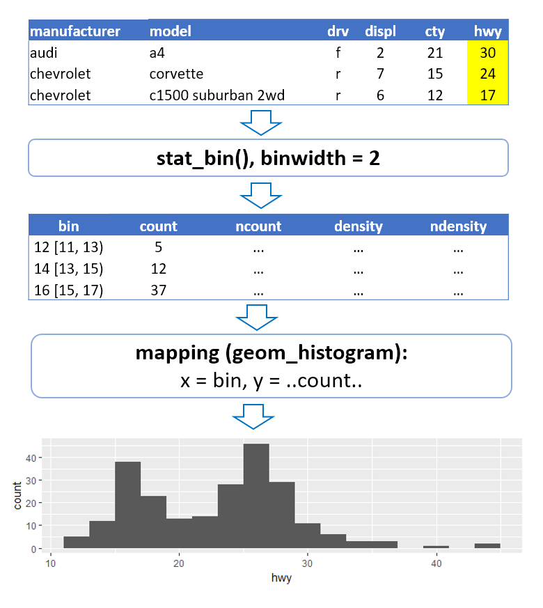

Путь от данных к графику в ggplot2

Детали отображения данных на визуальные характеристики настраиваются при помощи шкал (**scales**). Например, шкалы позволяют задать соответствие цветов и категорий в данных, установить нужный порядок категорий, применить нелинейное преобразование, чтобы сделать зависимость более явной, избавиться от выбросов, ограничив диапазон выводимых данных…

Шкалы помещают данные в некоторую **систему координат**. Чтобы показать результат на экране, применяются функции для работы с координатными системами (**coord**). Обычно это происходит автоматически, но вы можете вмешаться в процесс - например, поменять местами оси координат, чтобы сделать подписи на графике более читаемыми, или увеличить интересующую вас часть графика.

Также мы рассмотрели еще один способ для оценки влияния категориальной переменной - разделение на панели (**faceting**).

Шаблон кода для построения графиков выглядит так:

```
ggplot(data = <DATA>) +
  <GEOM_FUNCTION>(mapping = aes(<MAPPINGS>)) +
  <SCALE_FUNCTION> +
  <FACET_FUCTION> +
  <COORD_FUNCTION>
```

Практический пример:

```r
data(mpg)
head(mpg)
```

```
## # A tibble: 6 x 11
##   manufacturer model displ  year   cyl trans drv     cty   hwy fl    class
##   <chr>        <chr> <dbl> <int> <int> <chr> <chr> <int> <int> <chr> <chr>
## 1 audi         a4      1.8  1999     4 auto~ f        18    29 p     comp~
## 2 audi         a4      1.8  1999     4 manu~ f        21    29 p     comp~
## 3 audi         a4      2    2008     4 manu~ f        20    31 p     comp~
## 4 audi         a4      2    2008     4 auto~ f        21    30 p     comp~
## 5 audi         a4      2.8  1999     6 auto~ f        16    26 p     comp~
## 6 audi         a4      2.8  1999     6 manu~ f        18    26 p     comp~
```

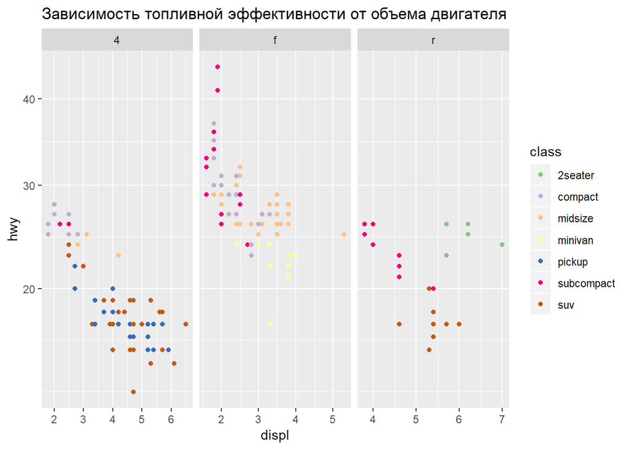

```r
ggplot(data = mpg) +
  geom_point(mapping = aes(x = displ, y = hwy, color = class)) +
  scale_color_brewer(palette = 'Accent') +
  scale_y_sqrt() +
  facet_wrap(~drv, scales = 'free_x') +
  labs(title = 'Зависимость топливной эффективности от объема двигателя')
```

В этой части будет рассмотрена работа со слоями, а также вопросы визуализации категориальных данных.

# Слои

**Слои** (**layers**) позволяют комбинировать на одной визуализации различные представления данных. Например, тренды, опорные линии, метки наблюдений и аннотации могут быть добавлены на одну визуализацию как отдельные слои.

Чтобы добавить новые слои, вы можете включить в код для построения графика любое количество функций `geom_...()` или `stat_...()`:

```
ggplot(data = <DATA>) +
  <GEOM_FUNCTION>(mapping = aes(<MAPPINGS>)) +
  <GEOM_FUNCTION>(mapping = aes(<MAPPINGS>)) +
  <STAT_FUNCTION>(mapping = aes(<MAPPINGS>)) +
  ...
```

Каждый слой может иметь свой набор соответствий между столбцами таблицы данных и эстетиками. При этом, если какие-то соответствия - одни и те же для нескольких слоев, то удобно вынести их из определения слоя в вызов функции `ggplot()`. В этом случае придется задавать соответствие только один раз.

## Пример: добавление линии тренда на график

Построим визуалиазацию зависимости топливной эффективности от размера двигателя для машин с разным типом привода.

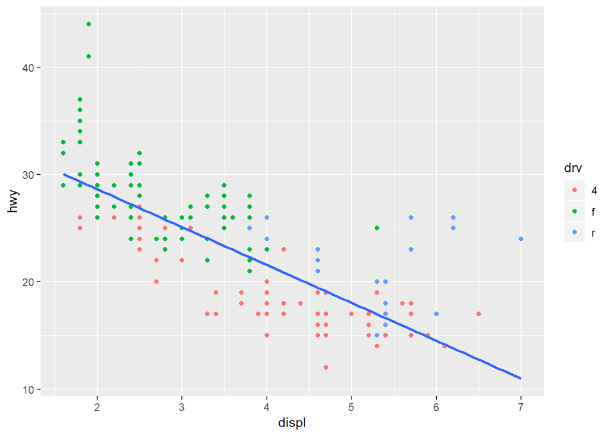

```r
ggplot(data = mpg,
       mapping = aes(x = displ, y = hwy)) + # общие для всех слоев связи
  geom_point(mapping = aes(color = drv)) + # x и y уже заданы, добавляем цвет
  geom_smooth(method = 'lm', se = FALSE) # x и y уже заданы
```

Здесь данные заданы в `ggplot()`, поэтому они используются всеми слоями. Две связи - для эстетик `x` и `y` - также заданы сразу для всех слоев, поэтому в `geom_point()` добавляется только связь для цвета, а в `geom_smooth()` вообще не требуется задавать никаких связей.

## Упражнение: добавление трендов для подгрупп

Используя набор данных `diamonds`:

```r
data(diamonds)
head(diamonds)
```

```
## # A tibble: 6 x 10
##   carat cut       color clarity depth table price     x     y     z
##   <dbl> <ord>     <ord> <ord>   <dbl> <dbl> <int> <dbl> <dbl> <dbl>
## 1 0.23  Ideal     E     SI2      61.5    55   326  3.95  3.98  2.43
## 2 0.21  Premium   E     SI1      59.8    61   326  3.89  3.84  2.31
## 3 0.23  Good      E     VS1      56.9    65   327  4.05  4.07  2.31
## 4 0.290 Premium   I     VS2      62.4    58   334  4.2   4.23  2.63
## 5 0.31  Good      J     SI2      63.3    58   335  4.34  4.35  2.75
## 6 0.24  Very Good J     VVS2     62.8    57   336  3.94  3.96  2.48
```

Напишите код, в точности воспроизводящий следующий график:

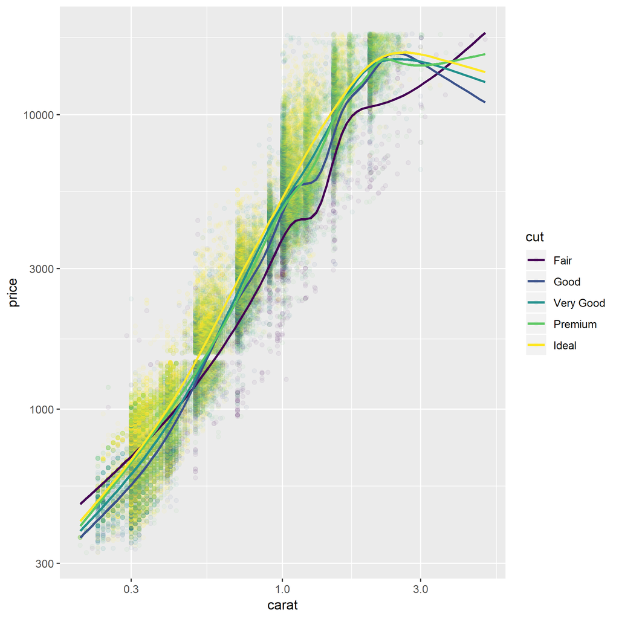

Упражнение - добавление трендов

**Совет:** вы можете открыть график в новом окне, кликнув по ссылке на него с нажатой клавшией `Shift`. Если RStudio жалуется на отсутствующий файл, - выполните команду меню: `Session/Set Working Directory/To Source File Location`, чтобы установить в качестве рабочей директории папку, в которой находится данный блокнот.

```r
# Раскомментируйте и допишите код:

#ggplot(data = diamonds, ...) +
#  geom_point(...) +
#  geom_smooth(...)
```

**Подсказки:**

- По умолчанию `geom_smooth()` будет строить нелинейные тренды, такие же как на этом графике.
- Чтобы тренд строился на всем диапазоне оси x, используйте аргумент `fullrange = TRUE` для `geom_smooth()`.

## Exercise: adding trend lines for subgroups

Attach the `diamonds` dataset:

```r
data(diamonds)
head(diamonds)
```

```
## # A tibble: 6 x 10
##   carat cut       color clarity depth table price     x     y     z
##   <dbl> <ord>     <ord> <ord>   <dbl> <dbl> <int> <dbl> <dbl> <dbl>
## 1 0.23  Ideal     E     SI2      61.5    55   326  3.95  3.98  2.43
## 2 0.21  Premium   E     SI1      59.8    61   326  3.89  3.84  2.31
## 3 0.23  Good      E     VS1      56.9    65   327  4.05  4.07  2.31
## 4 0.290 Premium   I     VS2      62.4    58   334  4.2   4.23  2.63
## 5 0.31  Good      J     SI2      63.3    58   335  4.34  4.35  2.75
## 6 0.24  Very Good J     VVS2     62.8    57   336  3.94  3.96  2.48
```

Write code to recreate the following plot:

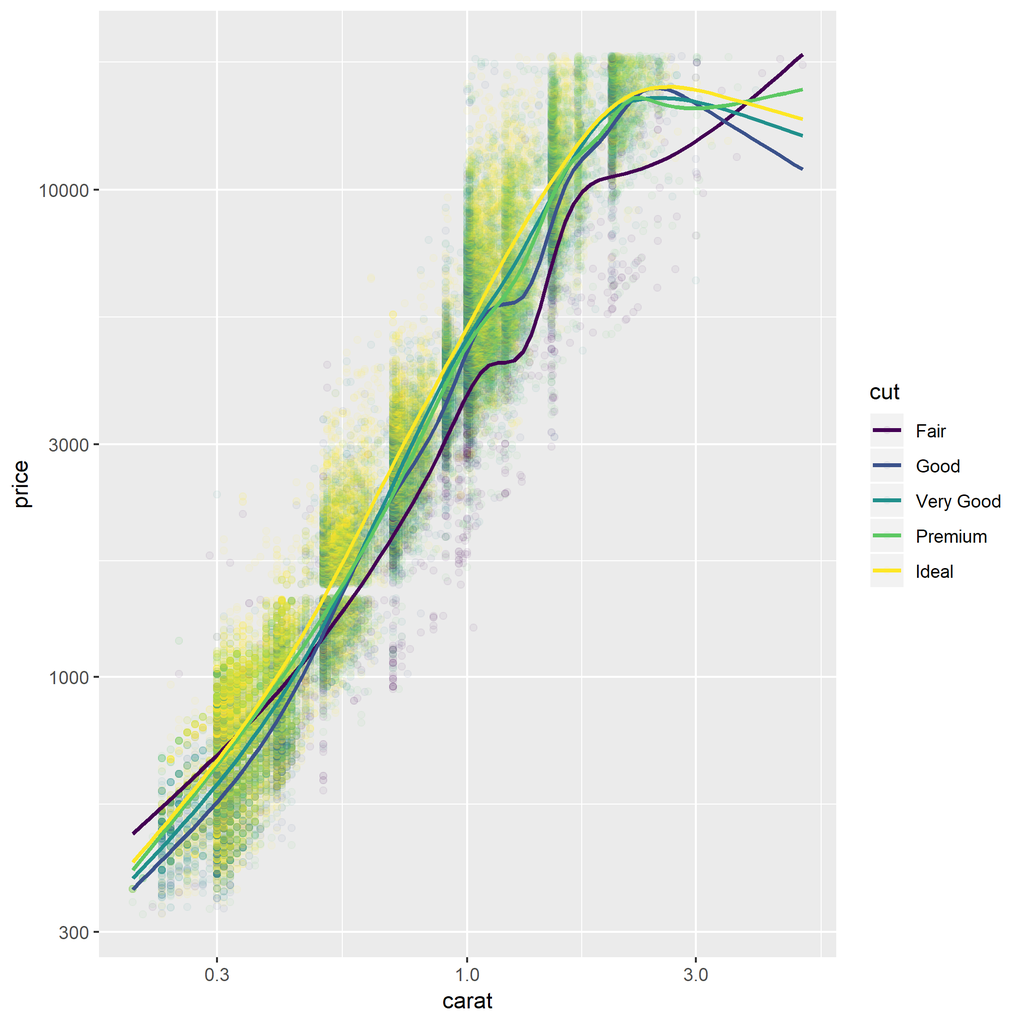

Exercise on adding trends

**Tip** you can enlarge the picture by **Shift-clicking** its link. If RStudio complains about a missing file - select `Session/Set Working Directory/To Source File Location` command in the menu. This will set the current directory to the one which contains the source file.

```r
# Uncomment and complete the following code

#ggplot(data = diamonds, ...) +
#  geom_point(...) +
#  geom_smooth(...)
```

**Tips**

- By default, `geom_smooth()` will add non-linear trends, same as in this plot
- To extend the trend line to the entire x axis range, use `fullrange = TRUE` argument when calling `geom_smooth()` function.

## Пример: выделение элементов на графике

В `ggplot2`, к сожалению, нет возможности интерактивно исследовать данные на визуализации, но можно понять, где находятся наблюдения с интересующими свойствами при помощи аннотаций. В качестве примера, выделим на графике все автомобили марки ‘dodge’:

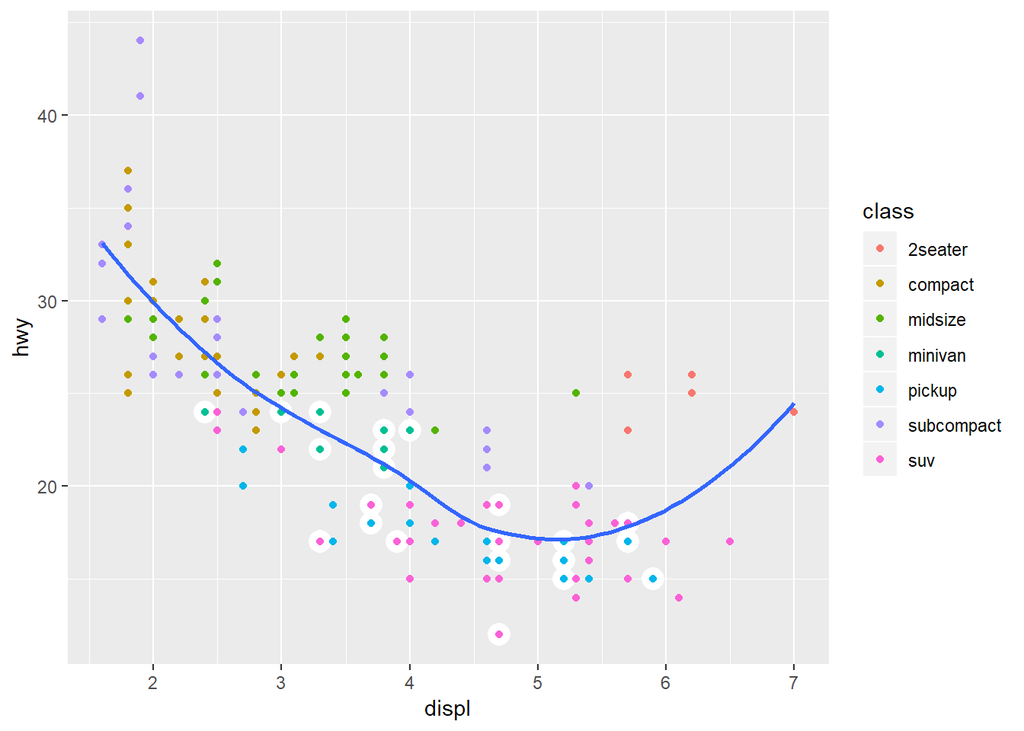

```r
ggplot(data = mpg,
       mapping = aes(x = displ, y = hwy)) +

  geom_point(data =
               filter(mpg, manufacturer == 'dodge'),
             color = 'white', size = 5) +

  geom_point(mapping = aes(color = class)) +

  geom_smooth(se = FALSE)
```

**Примечания:**  
- связи по умолчанию задаются в `ggplot()`, поэтому в последующих слоях не требуется связывать с данными эстетики `x` и `y`;  
- самый первый слой на графике использует свой, отдельный набор данных - таблицу, в которой отфильтрованы данные только по автомобилям `dodge`;  
- остальные слои используют данные, заданные в `ggplot()`;  
- порядок слоев важен, иначе более крупные точки закрывали бы более мелкие.

С другими видами аннотаций можно познакомиться в главе про оформление графиков книги [R for Data Science](http://r4ds.had.co.nz/graphics-for-communication.html#annotations).

## Пример: добавление опорных линий

На визуализациях полезно добавлять **опорные линии**. Например, таким образом можно показать, где находится центр распределения. Для добавления опорных линий используются функции `geom_hline()` и `geom_vline()`.

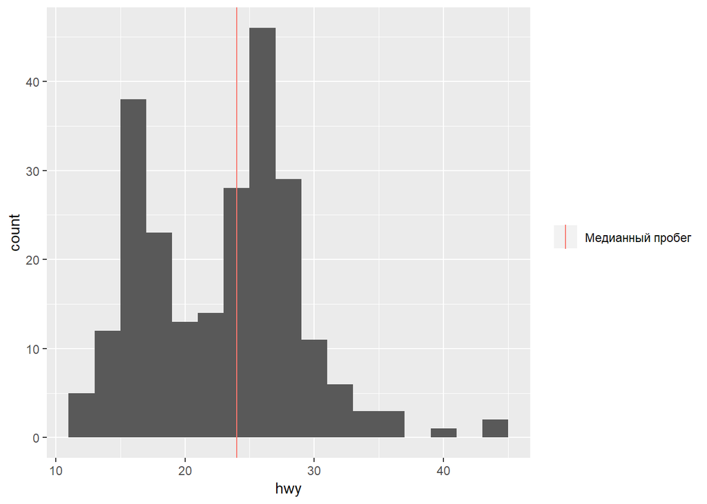

```r
ggplot(data = mpg) +
  geom_histogram(mapping = aes(x = hwy),
                 binwidth = 2)  +

  geom_vline(mapping =
               aes(xintercept = median(hwy),
                   color = 'Медианный пробег'),
             show.legend = TRUE) +

  labs(color = NULL)
```

**Примечания:**  
- положение линии задается эстетикой `xintercept`;  
- желательно использовать для нее связывание, а не определение, т.к. внутри функции `aes()` у вас есть доступ к именам столбцов в таблице данных для графика;  
- по умолчанию опорные линии не включаются в легенду, здесь мы явно потребовали это сделать.

## Пример: сравнение гистограммы и теоретического распределения

Чтобы проверить, соответствуют ли данные какому-либо теоретическому распределению - например, нормальному или экспоненциальному, - полезно сравнить гистограмму или плотность распределения с кривой теоретического распределения. Как это сделать, - смотрите в блокноте ggplot_plotting_functions.Rmd.

# Корректировка положения объектов (position adjustment)

## Проблема наложения данных (overplotting)

Часто встречается ситуация, когда данные в таблице приводятся с ограниченной точностью. Например, при указании возраста его обычно округляют до года. В нашем примере про автомобили округлены пробег на галлоне и объем двигателя.

Из-за дискретности значений, визуализация не позволяет правильно оценить, где сконцентрированы данные. Точки накладываются и закрывают друг друга. Один из способов борьбы с наложением (**overplotting**) - использование прозрачности.

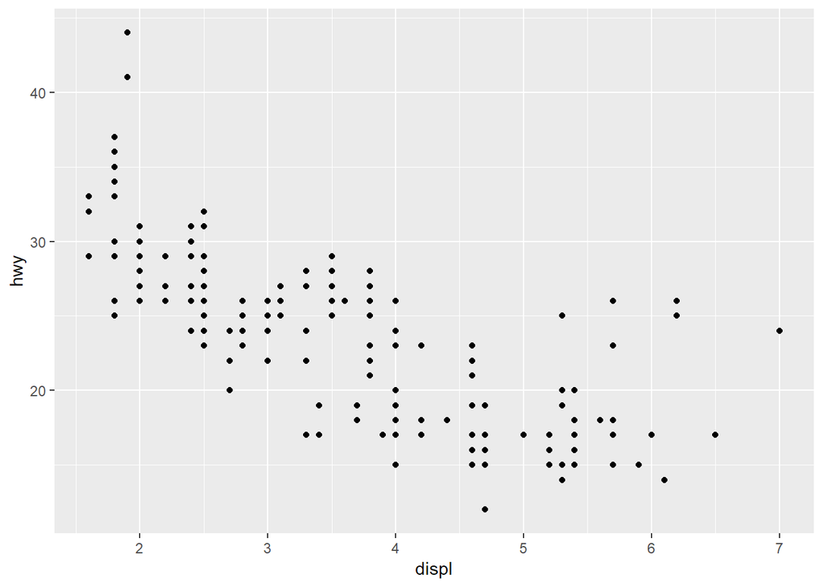

```r
# Исходный график с наложением
ggplot(data = mpg) +
  geom_point(mapping = aes(x = displ, y = hwy))
```

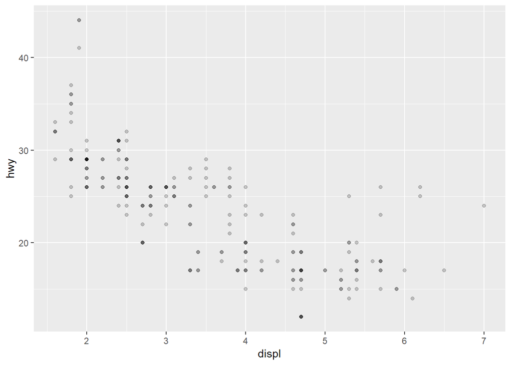

```r
# Прозрачность делает точки видимыми
ggplot(data = mpg) +
  geom_point(mapping = aes(x = displ, y = hwy),
             alpha = 0.2)
```

## Добавление шума к данным (jitter)

Существует и другой способ борьбы с наложением данных - можно сделать совпадающие точки видимыми, если добавить к данным небольшой случайный шум (jitter). Это можно сделать прямо в процессе визуализации, поскольку `ggplot2` позволяет вносить изменения в расположение объекта (**position adjustments**).

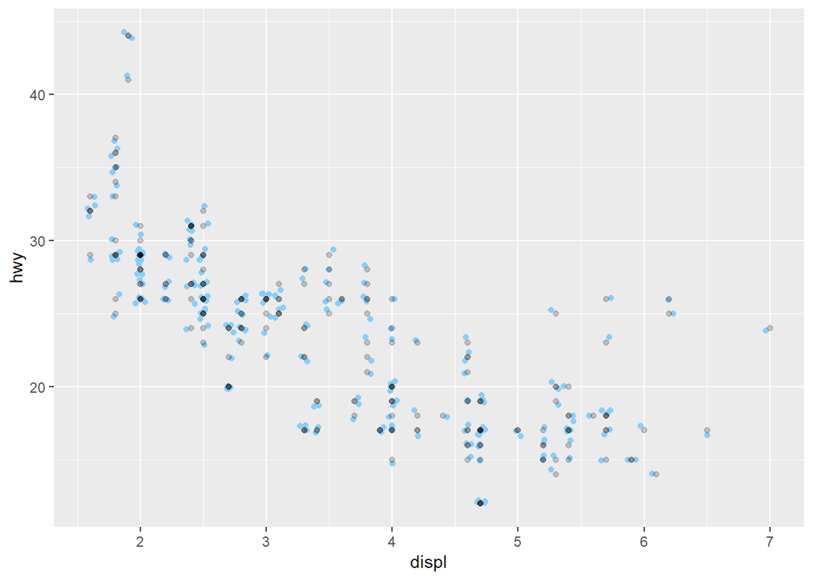

```r
ggplot(data = mpg,
       mapping = aes(x = displ, y = hwy)) +

  geom_point(position = 'jitter',
             color = 'lightskyblue') +

  geom_point(alpha = 0.2)
```

Поскольку добавление шума с целью сделать данные видимыми - распространенный прием, в `ggplot2` для удобства сделана отдельная функция - `geom_jitter()`:

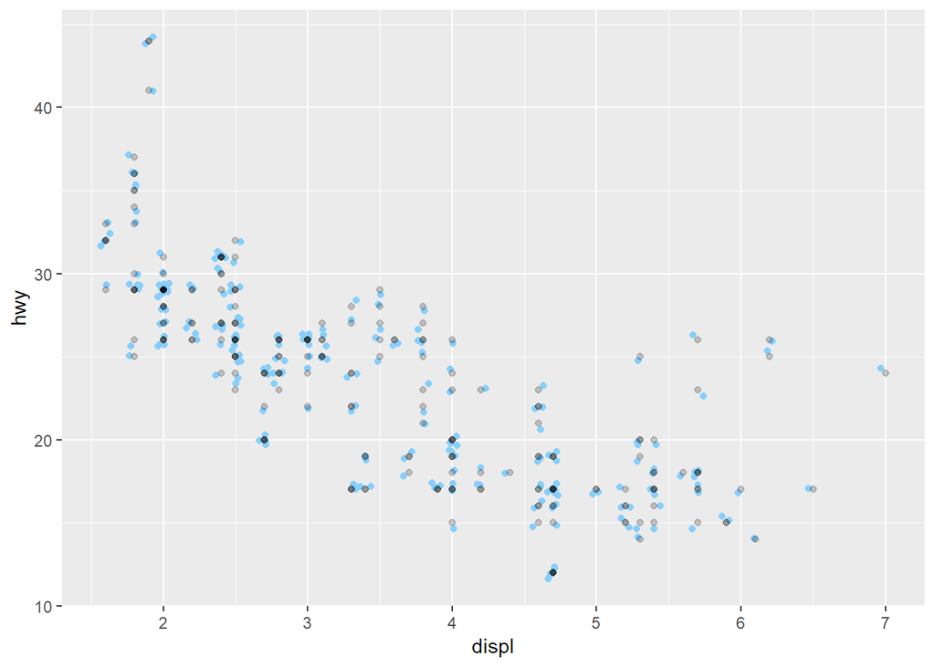

```r
ggplot(data = mpg,
       mapping = aes(x = displ, y = hwy)) +

  geom_jitter(color = 'lightskyblue') +

  geom_point(alpha = 0.2)
```

Корректировка положения полезна и для других типов геомов. С применением этой функции для столбиковых диаграмм вы познакомитесь в следующем разделе.

## Столбиковые диаграммы для визуализации категориальных данных

Столбиковые диаграммы используются для визуализации распределений категориальных данных. Например, мы можем исследовать частоту упоминания различных типов автомобилей в данных о топливной эффективности:

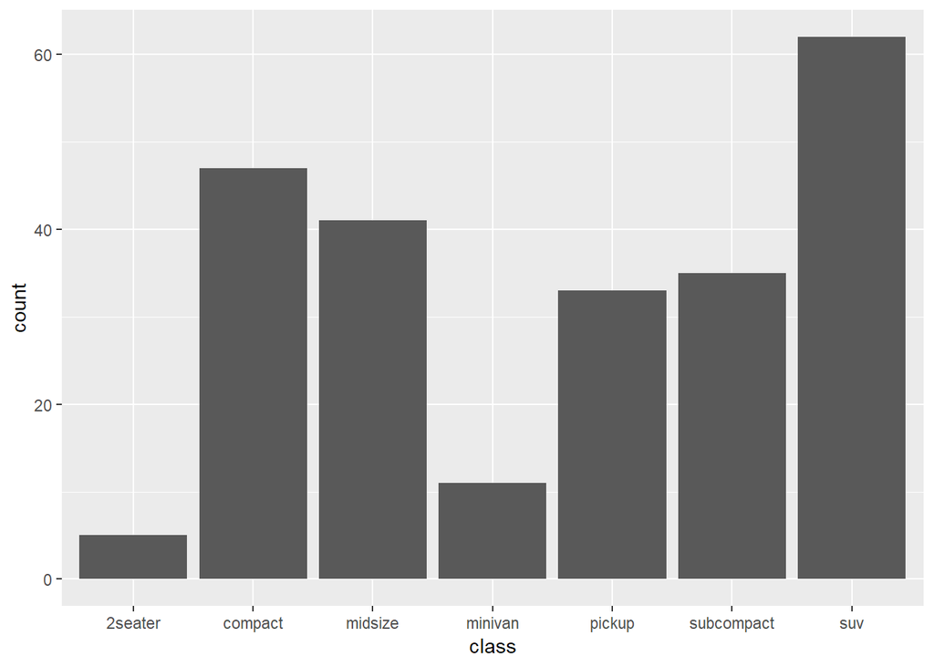

```r
ggplot(data = mpg) +
  geom_bar(mapping = aes(x = class))
```

### Условные распределения категориальных переменных (`position = 'stack'`)

Этот же прием мы можем использовать и для анализа связей между двумя категориальными переменными. Столбики можно использовать, чтобы визуализировать условное распределение одной категориальной переменной в зависимости от значения другой категориальной переменной. Сравним, например, количество автомобилей с разным типом привода в зависимости от класса автомобиля.

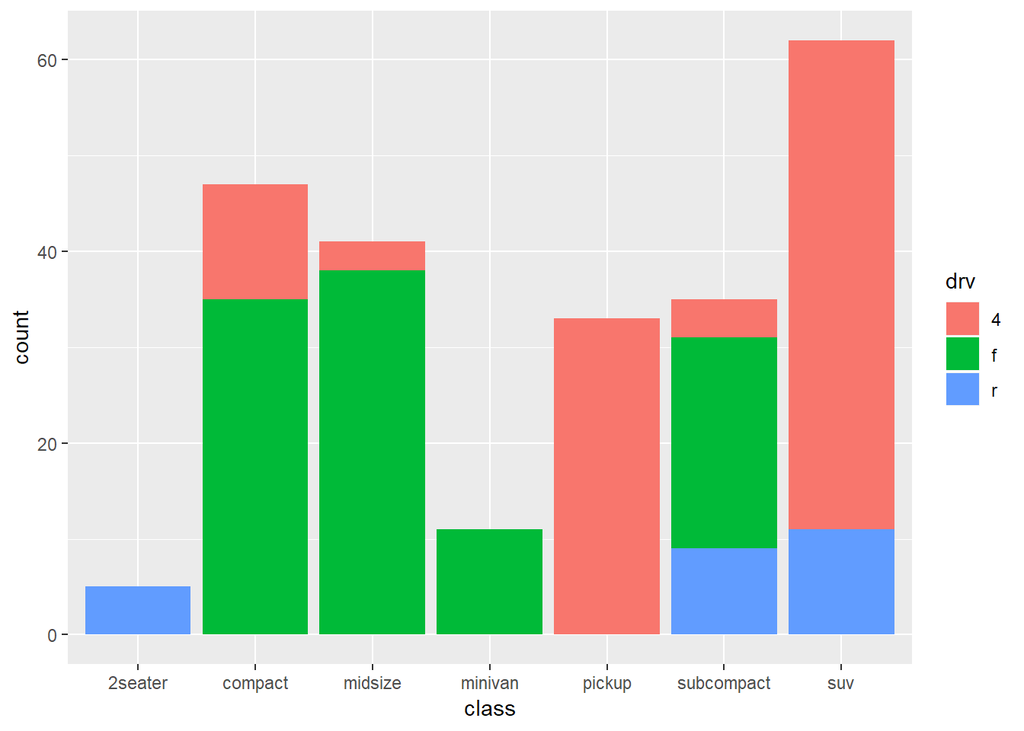

```r
ggplot(data = mpg) +
  geom_bar(mapping = aes(x = class, fill = drv))
```

Здесь мы можем видеть, что все 2-местные автомобили - заднеприводные, все пикапы и большинство “паркетников” (SUV) - полноприводные, а автомобили других классов, в основном, имеют передний привод.

Наблюдая на графике различие в распределении машин по типу привода внутри каждого класса, можно сделать вывод о том, что между этими двумя характеристики автомобилей есть зависимость.

Заметим, что:

> переменная, которую мы рассматриваем как зависимую, обычно визуализируется при помощи цвета, а переменная-фактор - как категории по оси `x`.

Иногда роли переменных взаимозаменяемы, однако при этом меняется интерпретация результата. Предыдущий график отвечал на вопрос: *“Какая доля пикапов имеет полный привод?”* А этот - на вопрос: *“Какая доля полноприводных машин - пикапы?”*

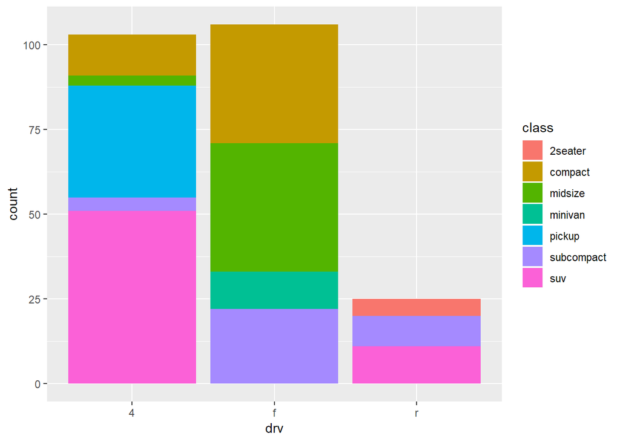

```r
ggplot(data = mpg) +
  geom_bar(mapping = aes(x = drv, fill = class))
```

Стоит помнить о том, что человеку сложно различать большое количество цветов, поэтому при выборе эстетики для связывания с данными

> переменную с большим количеством категорий лучше связать с эстетикой `x`.

Или подумайте о том, как объединить группы, чтобы уменьшить их количество (см. раздел про операции с факторами).

### Нормировка частот (`position = 'fill'`)

Анализ распределения на предыдущей визуализации затруднен, поскольку количество автомобилей разных классов в выборке различается. Мы можем облегчить сравнение распределений путем перехода к относительным величинам - долям внутри каждой категории по оси x. Это легко сделать, используя корректировку положения. Достаточно добавить в описании геома `position = 'fill'`.

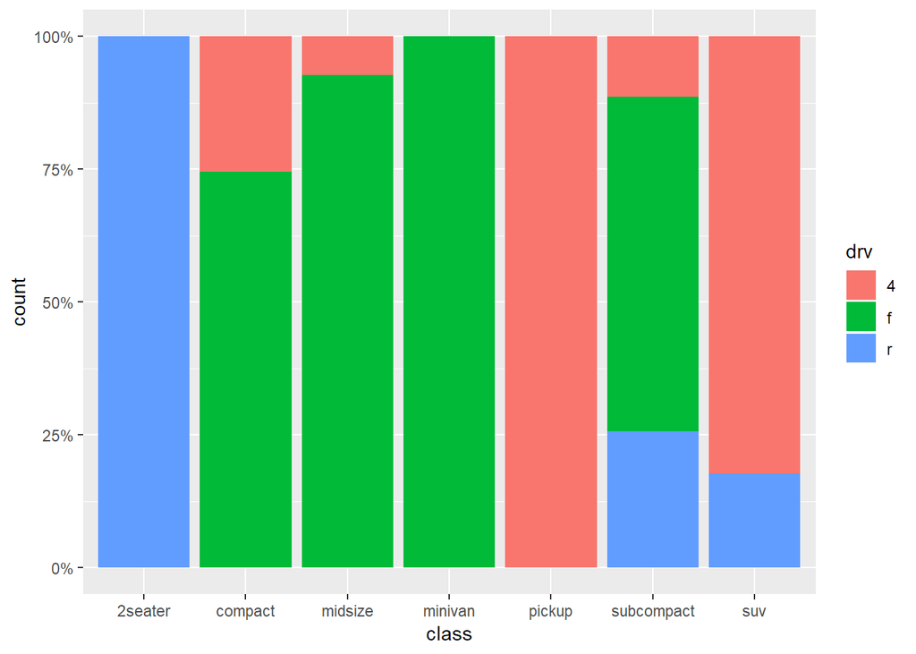

```r
ggplot(data = mpg) +
  geom_bar(mapping = aes(x = class, fill = drv),
           position = 'fill') +
  scale_y_continuous(labels = scales::percent) # процентный формат для оси
```

Заметим, что по умолчанию столбиковые диаграммы используют `position = 'stack'` (см. предыдущий пример) - цветные столбики ставятся друг на друга.

Для столбиковых диаграмм существует и еще один вариант корректировки положения: `position = 'dodge'`, при котором цветные столбики помещаются другом рядом с другом. Этот режим удобно использовать для визуализации числовых характеристик групп.

### Упражнение: зависимость качества огранки бриллианта и прозрачности

Используя визуализацию набора данных `diamonds`, ответьте на вопрос: связаны ли качество огранки бриллианта (`cut`) и прозрачность (`clarity`)?

Какой вариант связывания переменных с эстетиками, на ваш взгляд, более информативен?

```r
#ggplot(data = diamonds) +
  #geom_bar(...)
```

### Exercise: relationship between diamond’s cut and clarity

Create a visualization answering the question, if the diamond’s `cut` and `clarity` are related.

Try a few options for mapping variables to aesthetics. Which one is the most useful?

```r
#ggplot(data = diamonds) +
  #geom_bar(...)
```

### Столбиковые диаграммы для визуализации числовых характеристик групп

Для сравнения групп можно использовать и количественные показатели. В этом случае высота столбика для подгруппы будет определяться не количеством наблюдений в ней, а некоторой числовой характеристикой распределения.

Например, мы можем проверить, совпадают ли центры распределений количественного показателя в подгруппах, сравнив средние или медианы. Также можно сравнивать стандартные отклонения или межквартильные размахи, чтобы сравнить “ширину” распределений в подгруппах.

Необходимые числовые характеристики можно получить прямо в процессе построения графика, изменив статистическую функцию для геома:

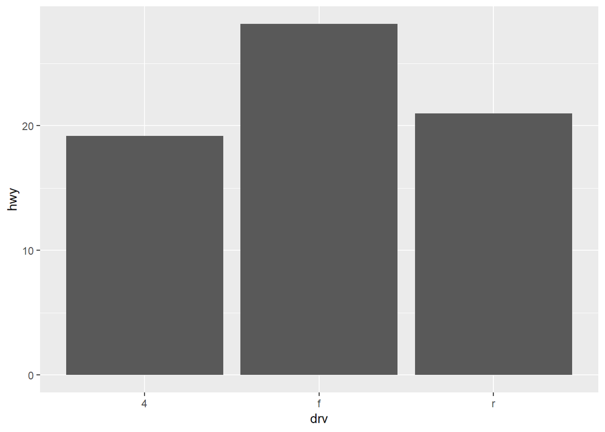

```r
ggplot(data = mpg, mapping = aes(x = drv, y = hwy)) +
  geom_bar(stat = 'summary', fun.y = 'mean')
```

Вспомним, что статистические функции в `ggplot2` имеют связанные геомы, а также могут добавляться как слои на график. Предыдущую визуализацию можно получить, используя статистическую функцию напрямую:

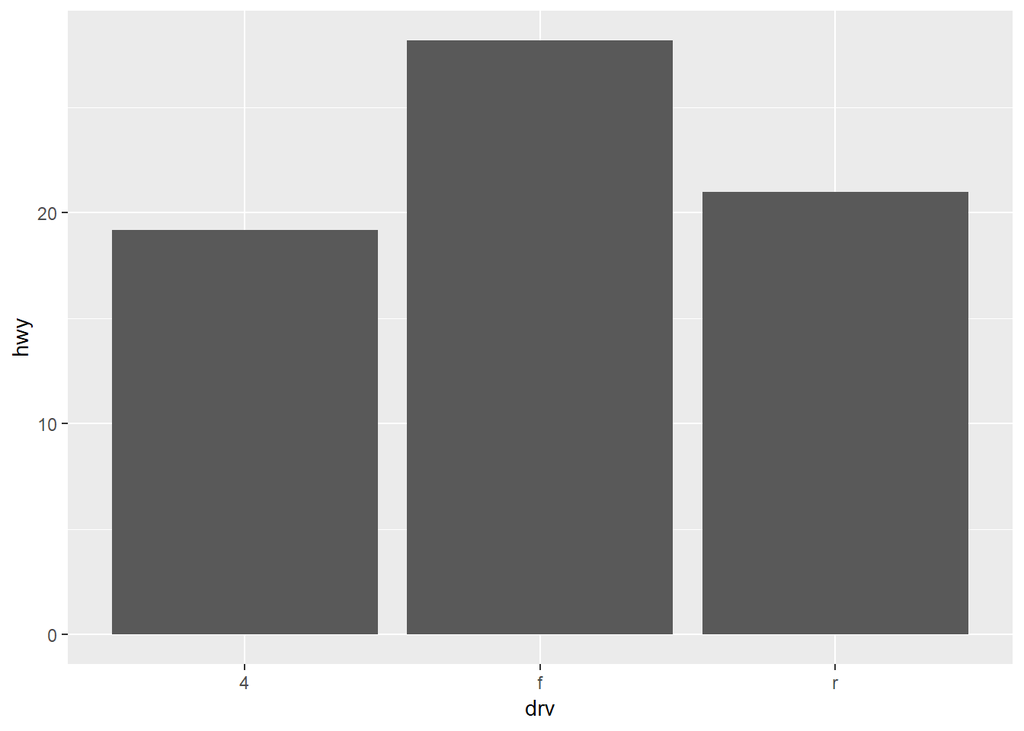

```r
ggplot(data = mpg, mapping = aes(x = drv, y = hwy)) +
  stat_summary(fun.y = 'mean', geom = 'bar')
```

### Сравнение числовых характеристик в подгруппах (`position = 'dodge'`)

Используя рассмотренные ранее техники, мы можем изучать и более сложные зависимости - например, связь между двумя категориальными и одной непрерывной переменной. В качестве примера, сравним, изменилась ли с течением времени топливная эффективность для машин c разным типом привода.

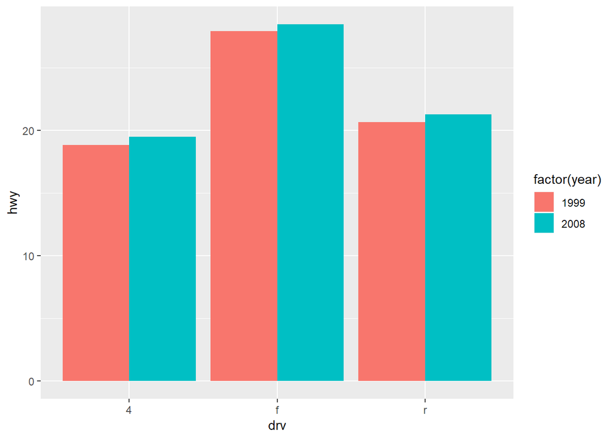

```r
ggplot(data = mpg,
       mapping = aes(x = drv,
                     fill = factor(year),
                     y = hwy)) +
  stat_summary(fun.y = 'mean', geom = 'bar',
               position = 'dodge')
```

**Замечание** по умолчанию, переменные числовых типов считаются количественными, поэтому в этом примере потребовалось явным образом указать, что годы выпуска должны рассматриваться как категории, создав факторную переменную при помощи `factor()`. В противном случае мы не получили бы нужного результата.

Заметим также, что вместо столбиков для решения подобной задачи можно использовать и ящичные диграммы, которые дают более полную характеристику распределения:

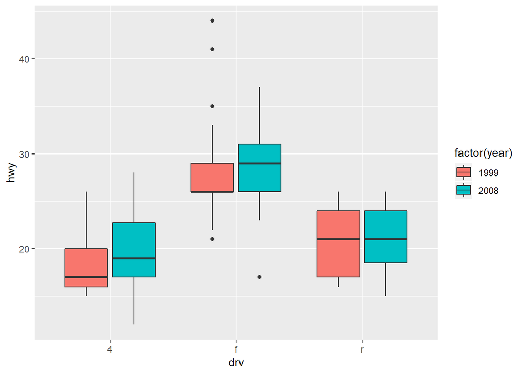

```r
ggplot(data = mpg,
       mapping = aes(x = drv,
                     fill = factor(year),
                     y = hwy)) +
  geom_boxplot()
```

Интересно, что эта визуализация показывает несколько другую картину: прогресс для полноприводных и переднеприводных машин оказался более существенным, а в категории заднеприводных автомобилей - практически отсутствует. Рост средней эффективности в этой группе обеспечивается за счет “сжатия” распределения благодаря прекращению выпуска машин с низкой эффективностью.

# Управление порядком категорий при помощи факторных переменных

## Факторы

**Фактор** (**factor**) - это еще один тип данных в R, который используется для хранения категориальных данных. Главным преимуществом факторов является возможность задавать требуемый порядок сортировки категорий.

Обычные текстовые переменные всегда сортируются по алфавиту:

```r
days <- c('We', 'Tu', 'Th', 'Mo', 'Su', 'Sa', 'Fri')
sort(days)
```

```
## [1] "Fri" "Mo"  "Sa"  "Su"  "Th"  "Tu"  "We"
```

Однако мы можем создать факторную переменную с правильным порядком категорий. Порядок категорий, или **уровней фактора** можно задать при помощи аргумента `levels =`.

```r
days_factor <-
  factor(days,
         levels = c('Mo', 'Tu', 'We', 'Th',
                    'Fri', 'Sa', 'Su'))
sort(days_factor)
```

```
## [1] Mo  Tu  We  Th  Fri Sa  Su
## Levels: Mo Tu We Th Fri Sa Su
```

С помощью функции `str()` можно убедиться, что факторы в R реализованы в виде целочисленных переменных, в которых каждому уровню соответствует некоторый числовой код:

```r
str(days_factor)
```

```
##  Factor w/ 7 levels "Mo","Tu","We",..: 3 2 4 1 7 6 5
```

## Факторы и порядок категорий на графике

С точки зрения визуализации данных факторы важны, поскольку они позволяют задать нужный порядок категорий на графиках.

Например, если мы хотим, чтобы типы привода всегда располагались в порядке: `f`, `r`, `4`, то можно сделать эту переменную факторной:

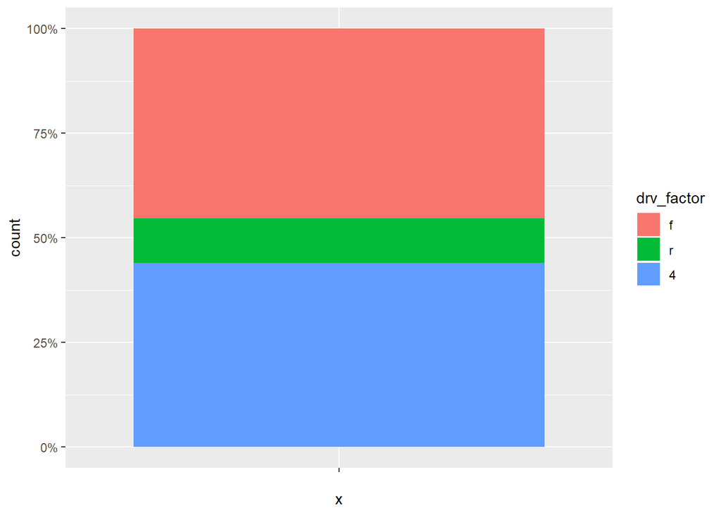

```r
mpg <- mutate(mpg,
              drv_factor =
                factor(drv, levels = c('f', 'r', '4')))

ggplot(data = mpg) +
  geom_bar(mapping = aes(x = "", fill = drv_factor),
           position = 'fill') +
  scale_y_continuous(labels = scales::percent)
```

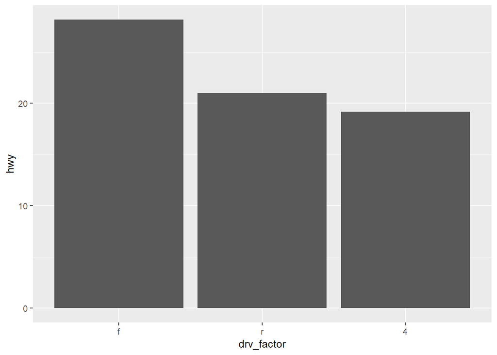

```r
ggplot(data = mpg) +
  stat_summary(mapping = aes(x = drv_factor, y = hwy),
               fun.y = 'mean', geom = 'bar')
```

**Замечание** Если нужно задать определенный порядок категорий разово, то можно это сделать прямо внутри функции `aes()`, не создавая новую факторную переменную в таблице данных.

## Сортировка уровней фактора

При сравнении категорий удобно, когда они расположены по возрастанию или убыванию отображаемого на графике показателя. Для сортировки уровней фактора удобно использовать функции пакета `forcats`:

- `fct_infreq()` - сортировка по убыванию частоты,
- `fct_reorder()` - сортировка по заданному показателю,
- `fct_rev()` - сортировка в обратном порядке.

### Пример: упорядочение категорий по частоте упоминания - `fct_infreq()`

Получим рейтинг ‘популярности’ автопроизводителей по количеству автомобилей в наборе данных `mpg`:

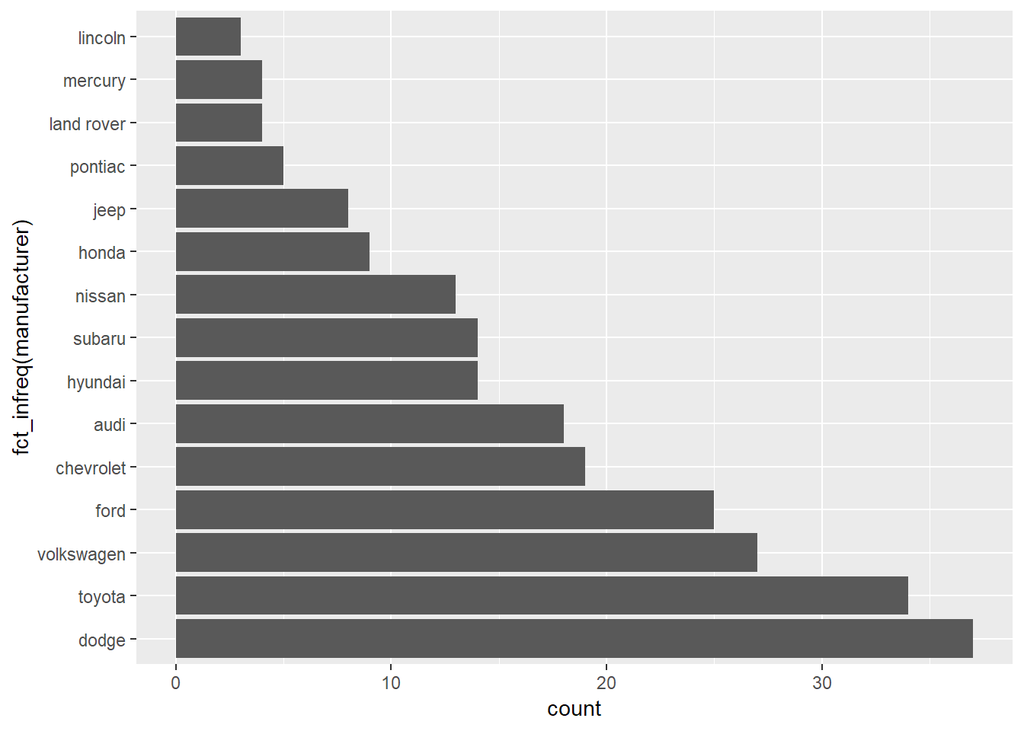

```r
ggplot(data = mpg,
       mapping = aes(x = fct_infreq(manufacturer))) +
  geom_bar() +
  coord_flip()
```

При необходимости, мы можем поменять порядок категорий на обратный:

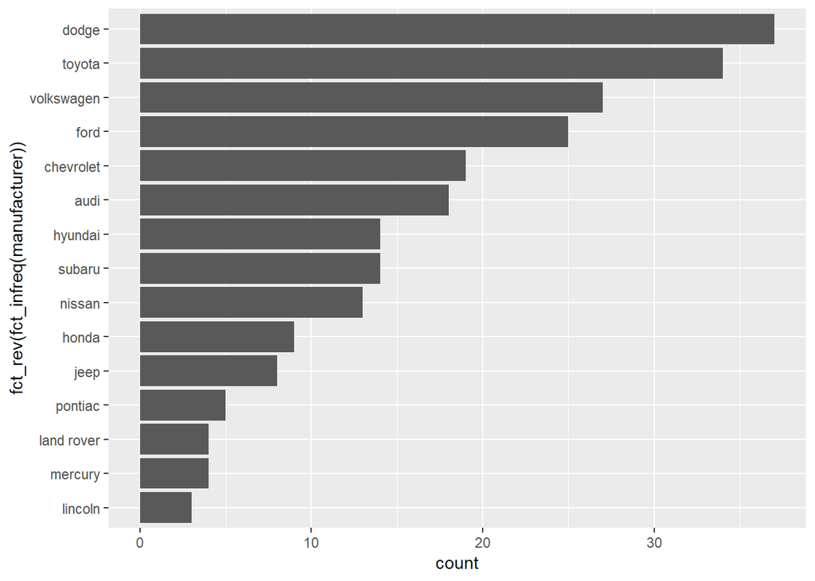

```r
ggplot(data = mpg,
       mapping =
         aes(x = fct_rev(fct_infreq(manufacturer)))) +
  geom_bar() +
  coord_flip()
```

### Пример: упорядочение категорий по числовому показателю - `fct_reorder()`

Упорядочить уровни фактора по числовому показателю можно при помощи функции `fct_reorder()`. Требуется указать, в какой переменной находится этот показатель, и агрегирующую функцию.

Составим рейтинг классов автомобилей по топливной эффективности:

[figure not shown]

```r
ggplot(data = mpg,
       mapping =
         aes(x = fct_reorder(class, hwy,
                             fun = mean,
                             .desc = TRUE),
             y = hwy)) +

  stat_summary(fun.y = 'mean', geom = 'bar') +
  labs(x = 'class')
```

### Упражнение: зависимость медианной цены бриллианта от качества огранки

Используя набор данных `diamonds`, постройте визуализацию медианной цены бриллианта за карат в зависимости от качества огранки (`cut`). Категории должны быть упорядочены по убыванию медианной цены за карат.

```r
# Напишите здесь свой код
```

### Exercise: relationship between median diamond price and cut

Using the `diamonds` dataset, visualize the relationship between median price per carat and `cut`. The categories must be ordered by decreasing median price per carat.

```r
# Write your code here
```

### Полезные операции с факторами

Здесь мы рассмотрели лишь несколько операций с факторами, необходимые для упорядочения категорий на графиках. Однако часто требуется решить и другие задачи:

- переместить несколько уровней фактора в начало списка - `fct_relevel()`,
- перекодировать уровни фактора - `fct_recode()`,
- объединить несколько уровней фактора в одну группу - `fct_collapse()`,
- избавиться от малочисленных уровней, объединив их в группу - `fct_lump()`.

Примеры смотрите в главе [Factors](http://r4ds.had.co.nz/factors.html) книги R for Data Science, или в документации на соответствующие функции.

# Приложение. Подготовка данных для визуализации вручную

Пакет `ggplot2` позволяет вычислять необходимые для визуализации статистики прямо в процессе построения графика. Но в некоторых случаях может быть сложно добиться нужного результата. Тогда, возможно, более простым спобом будет подготовка данных к визуализации “вручную”. Для этого удобно использовать функции из пакета `dplyr`, который будет подробно рассмотрен в блокноте по трансформации данных.

Здесь же отметим важный с точки зрения визуализации момент: если данные были подготовлены для визуализации заранее, то, как правило, требуется отключить обработку их статистчиескими функциями, выбрав `stat = 'identity'`.

Мы уже строили рейтинг топливной эффективности различных классов машин. Теперь получим этот же график, подготовив для него данные заранее:

```r
# Готовим таблицу данных для рейтинга с помощью dplyr:
class_mpg <- mpg %>%
  group_by(class) %>%
  summarise(avg_hwy = mean(hwy)) %>%
  arrange(desc(avg_hwy))

# Таблица данных для рейтинга
class_mpg
```

```
## # A tibble: 7 x 2
##   class      avg_hwy
##   <chr>        <dbl>
## 1 compact       28.3
## 2 subcompact    28.1
## 3 midsize       27.3
## 4 2seater       24.8
## 5 minivan       22.4
## 6 suv           18.1
## 7 pickup        16.9
```

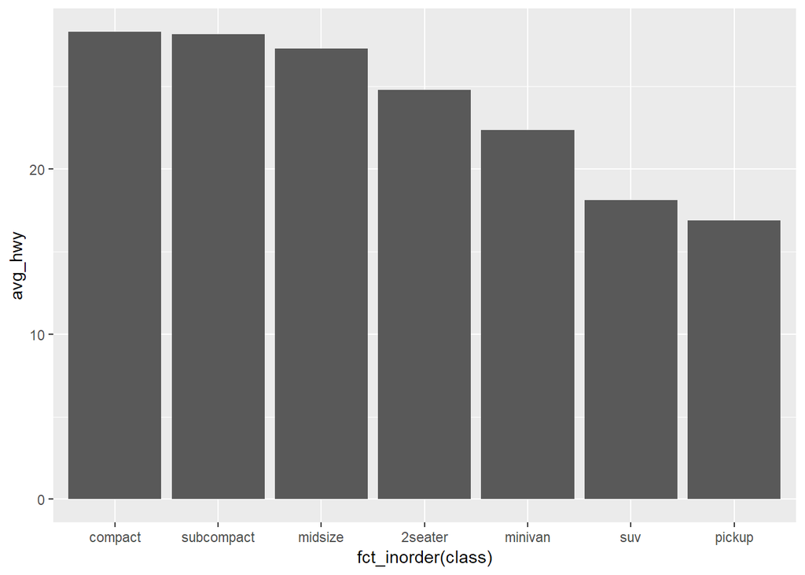

```r
# Визуализируем таблицу
ggplot(data = class_mpg,
       mapping =
         aes(x = fct_inorder(class), # уровни фактора - в порядке появления в таблице
             y = avg_hwy)) +

  geom_bar(stat = "identity")
```